# Problem Set 1

Pedro Scatimburgo

26/05/2022

# Preamble

In this problem set, I use the `tidyverse` package for easier data wrangling. I also define a `path` object that I use to load and save files from the Problem Set 1 folder. I load `data_gdp_brazil.csv` and then change the name of its columns to make the coding easier.

```r
# ---- Clears the environment ----

rm(list=ls())

# ---- Loads some packages ----

library(tidyverse)
library(quantmod)
library(doParallel)
library(gganimate)
library(transformr)
library(latex2exp)
# ---- Defines path and loads main file ----

# Defines path
path <- "C:\\Users\\psrov\\OneDrive - Fundacao Getulio Vargas - FGV\\Documentos\\EESP\\Disciplinas\\2 Tri\\Econometrics II\\Problem Sets\\Problem Set 1\\"

# Loads data_gdp_brazil
data_gdp_brazil <- readr::read_csv(paste0(path,"data\\data_gdp_brazil.csv"))
# Changes col names
colnames(data_gdp_brazil) <- c("data","gdp")
```

Now I will create the `xts` object instead of the original `data_gdp_brazil` as recommended. I will name it `df_xts`.

```r
df_xts <- xts::xts(x = data_gdp_brazil$gdp,
                   order.by = as.Date(x = as.character(data_gdp_brazil$data), format = "%Y"))
```

# Question 1

We have to report several objects for a total of eight models. I will loop the same code iterating over a vector that indicates which model I am estimating. This will be the `models` object, a list of vectors.

```r
# Creates list of models
models <- list(
  c(1,0,0),
  c(2,0,0),
  c(0,0,1),
  c(0,0,2),
  c(1,0,1),
  c(2,0,1),
  c(1,0,2),
  c(2,0,2)
)

# Creates a vector with the name of each model to make output more intuitive
models_names <- c("AR(1)","AR(2)","MA(1)","MA(2)","ARMA(1,1)","ARMA(2,1)","ARMA(1,2)","ARMA(2,2)")

# Creates a colorblind-friendly palette for the plot, which we will create later
cbPalette <- c("#999999", "#E69F00", "#56B4E9", "#009E73", "#F0E442", "#0072B2", "#D55E00", "#CC79A7")
```

Now I will iterate over each element of `models`. To report the objects asked in item a), I will use the function `coeftest` of package `lmtest`. To report the objects asked in item b), I will use functions `AIC` and `BIC`. To plot the forecast asked in item c) I will use `ggplot`.

I use `geom_ribbon` instead of `geom_line` to plot the confidence interval. I think it’s easier to see and it spares one line of code.

```
## RESULTS FOR THE AR(1) MODEL:
##
## z test of coefficients:
##
##           Estimate Std. Error z value  Pr(>|z|)
## ar1       0.287378   0.090503  3.1753  0.001497 **
## intercept 4.538021   0.538327  8.4299 < 2.2e-16 ***
## ---
## Signif. codes:  0 '***' 0.001 '**' 0.01 '*' 0.05 '.' 0.1 ' ' 1
##
## AIC: 691.989789088521
## BIC: 700.352264316867
```

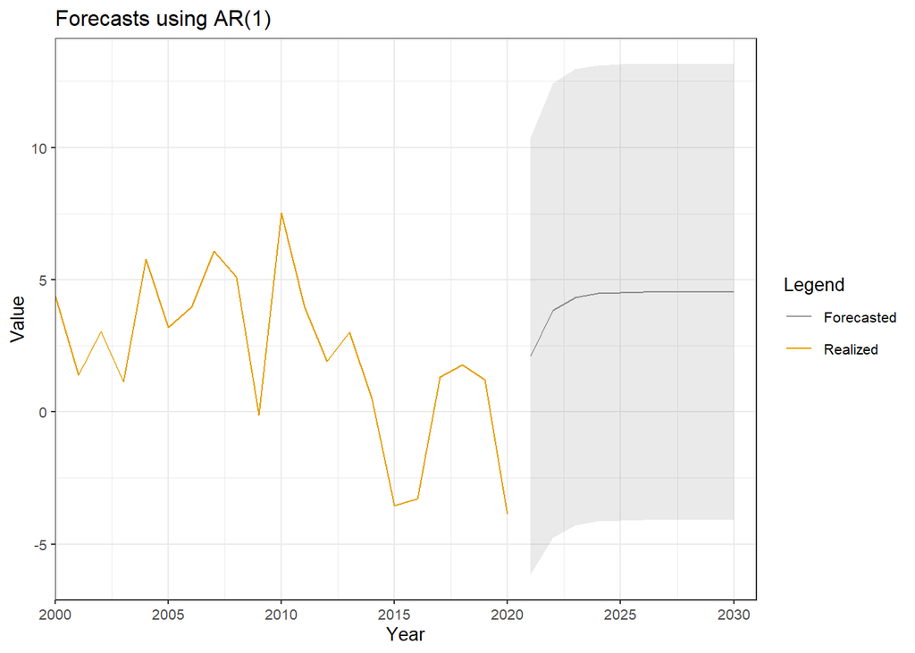

```
## RESULTS FOR THE AR(2) MODEL:
##
## z test of coefficients:
##
##           Estimate Std. Error z value  Pr(>|z|)
## ar1       0.250536   0.094226  2.6589   0.00784 **
## ar2       0.121827   0.094733  1.2860   0.19844
## intercept 4.526902   0.605134  7.4808 7.386e-14 ***
## ---
## Signif. codes:  0 '***' 0.001 '**' 0.01 '*' 0.05 '.' 0.1 ' ' 1
##
## AIC: 692.348680815006
## BIC: 703.498647786134
```

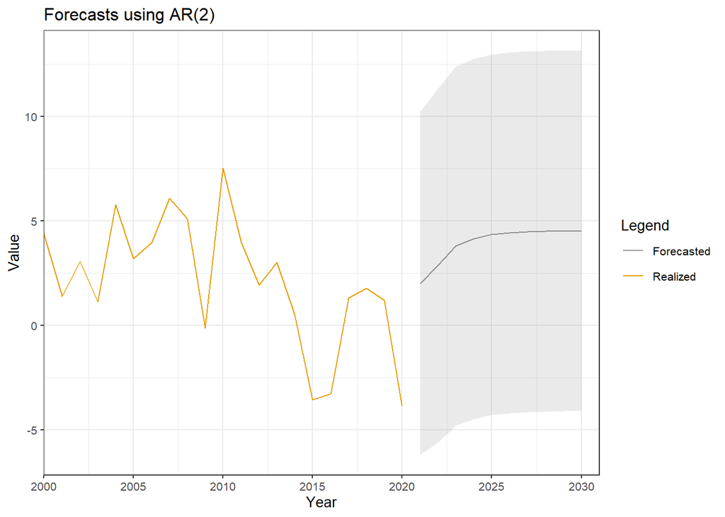

```
## RESULTS FOR THE MA(1) MODEL:
##
## z test of coefficients:
##
##           Estimate Std. Error z value  Pr(>|z|)
## ma1       0.238298   0.085548  2.7855  0.005344 **
## intercept 4.539330   0.479894  9.4590 < 2.2e-16 ***
## ---
## Signif. codes:  0 '***' 0.001 '**' 0.01 '*' 0.05 '.' 0.1 ' ' 1
##
## AIC: 693.97886250356
## BIC: 702.341337731906
```

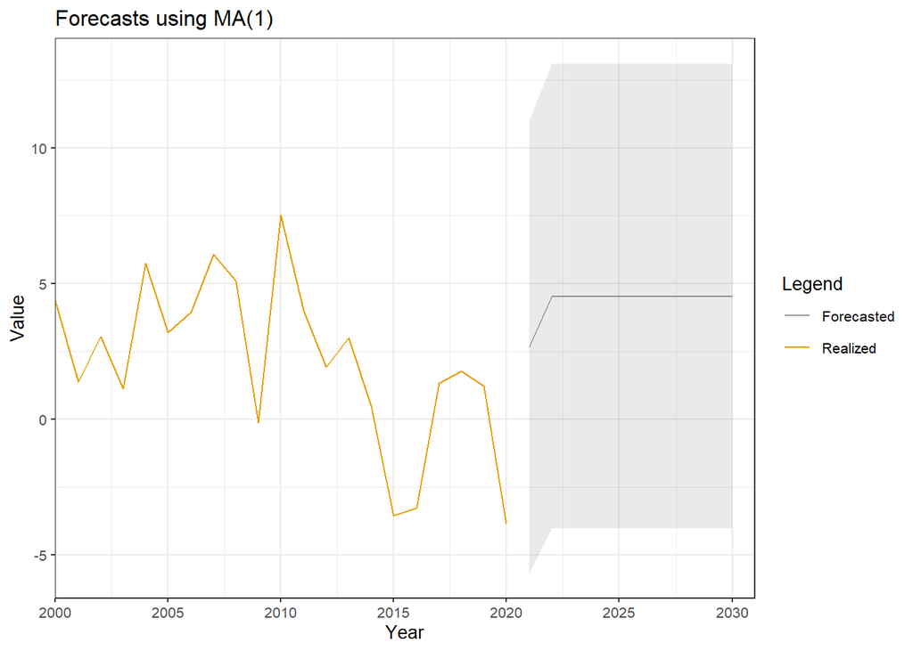

```
## RESULTS FOR THE MA(2) MODEL:
##
## z test of coefficients:
##
##           Estimate Std. Error z value Pr(>|z|)
## ma1       0.222084   0.094233  2.3567  0.01844 *
## ma2       0.158638   0.103410  1.5341  0.12501
## intercept 4.534940   0.529151  8.5702  < 2e-16 ***
## ---
## Signif. codes:  0 '***' 0.001 '**' 0.01 '*' 0.05 '.' 0.1 ' ' 1
##
## AIC: 693.717838525729
## BIC: 704.867805496857
```

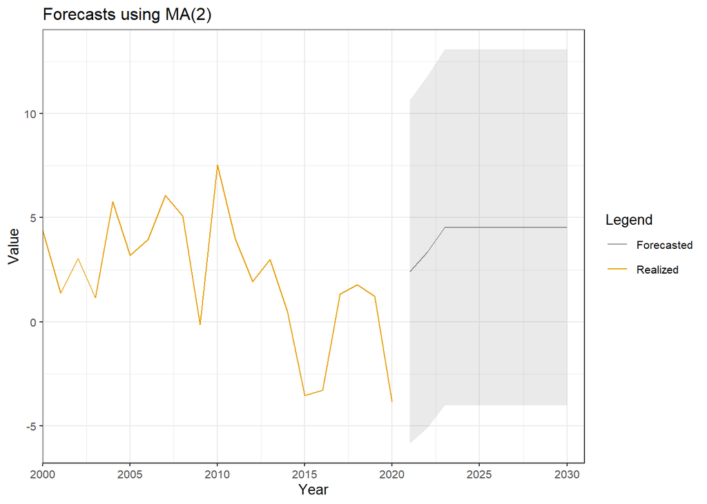

```
## RESULTS FOR THE ARMA(1,1) MODEL:
##
## z test of coefficients:
##
##           Estimate Std. Error z value  Pr(>|z|)
## ar1        0.74002    0.28361  2.6093  0.009073 **
## ma1       -0.51601    0.37467 -1.3773  0.168433
## intercept  4.49124    0.70623  6.3595 2.025e-10 ***
## ---
## Signif. codes:  0 '***' 0.001 '**' 0.01 '*' 0.05 '.' 0.1 ' ' 1
##
## AIC: 691.809094122862
## BIC: 702.95906109399
```

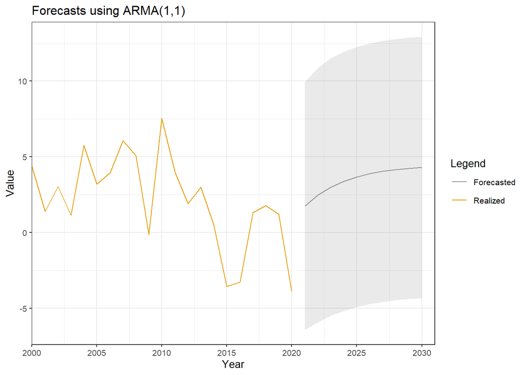

```
## RESULTS FOR THE ARMA(2,1) MODEL:
##
## z test of coefficients:
##
##           Estimate Std. Error z value  Pr(>|z|)
## ar1        1.10435    0.14164  7.7970 6.340e-15 ***
## ar2       -0.14886    0.11041 -1.3482    0.1776
## ma1       -0.87002    0.10158 -8.5649 < 2.2e-16 ***
## intercept  4.25915    1.07036  3.9792 6.915e-05 ***
## ---
## Signif. codes:  0 '***' 0.001 '**' 0.01 '*' 0.05 '.' 0.1 ' ' 1
##
## AIC: 692.547528085858
## BIC: 706.484986799769
```

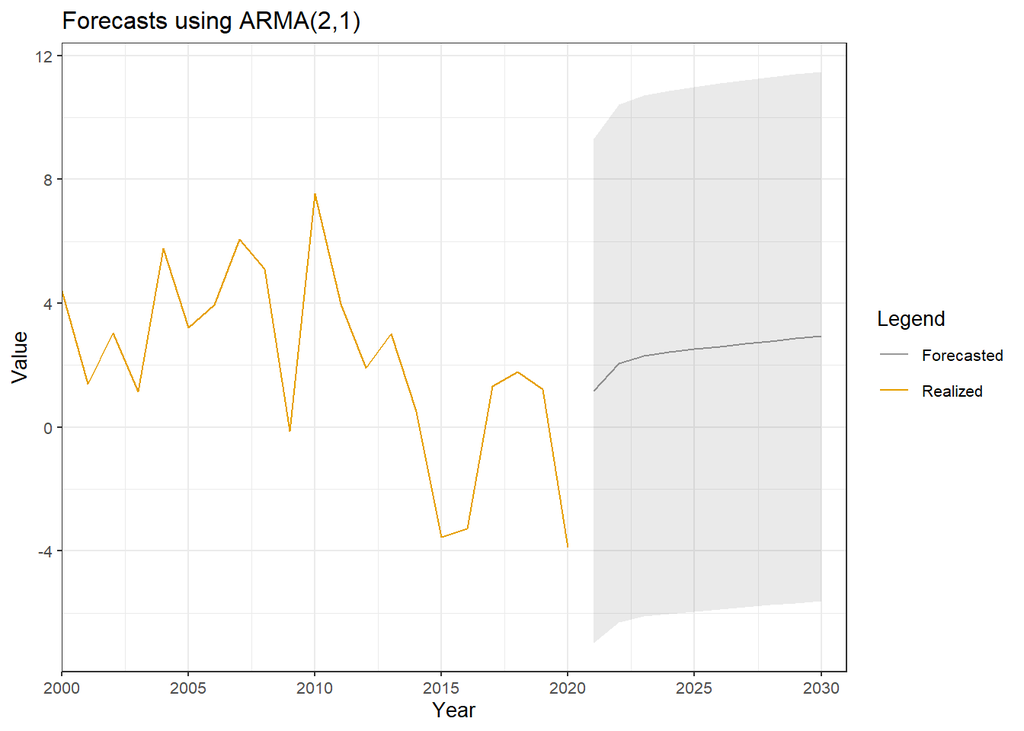

```
## RESULTS FOR THE ARMA(1,2) MODEL:
##
## z test of coefficients:
##
##            Estimate Std. Error z value  Pr(>|z|)
## ar1        0.944043   0.070232 13.4418 < 2.2e-16 ***
## ma1       -0.718604   0.118632 -6.0574 1.383e-09 ***
## ma2       -0.118525   0.096621 -1.2267    0.2199
## intercept  4.260475   1.072164  3.9737 7.076e-05 ***
## ---
## Signif. codes:  0 '***' 0.001 '**' 0.01 '*' 0.05 '.' 0.1 ' ' 1
##
## AIC: 692.728978409461
## BIC: 706.666437123371
```

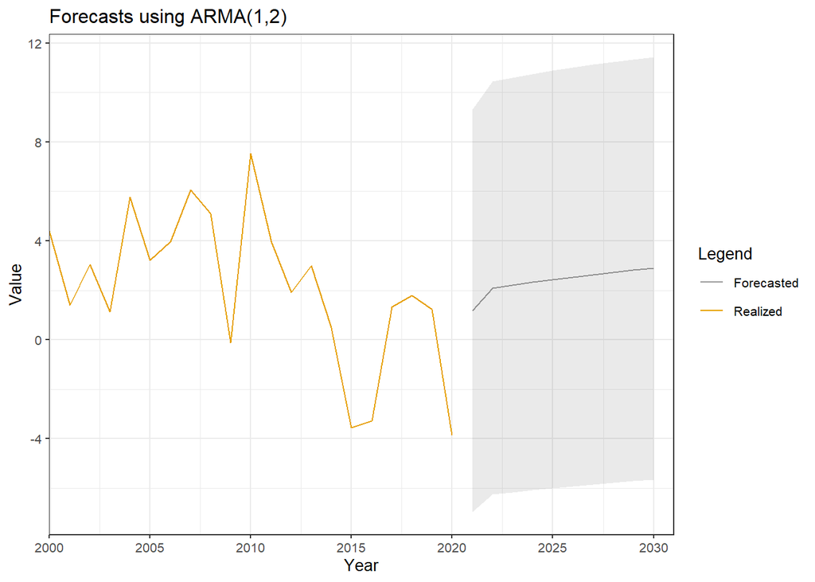

```
## RESULTS FOR THE ARMA(2,2) MODEL:
##
## z test of coefficients:
##
##           Estimate Std. Error z value  Pr(>|z|)
## ar1        1.29009    0.48308  2.6706  0.007572 **
## ar2       -0.32354    0.45257 -0.7149  0.474668
## ma1       -1.05859    0.49475 -2.1397  0.032382 *
## ma2        0.15588    0.41002  0.3802  0.703822
## intercept  4.26769    1.06426  4.0100 6.072e-05 ***
## ---
## Signif. codes:  0 '***' 0.001 '**' 0.01 '*' 0.05 '.' 0.1 ' ' 1
##
## AIC: 694.424485054399
## BIC: 711.149435511092
```

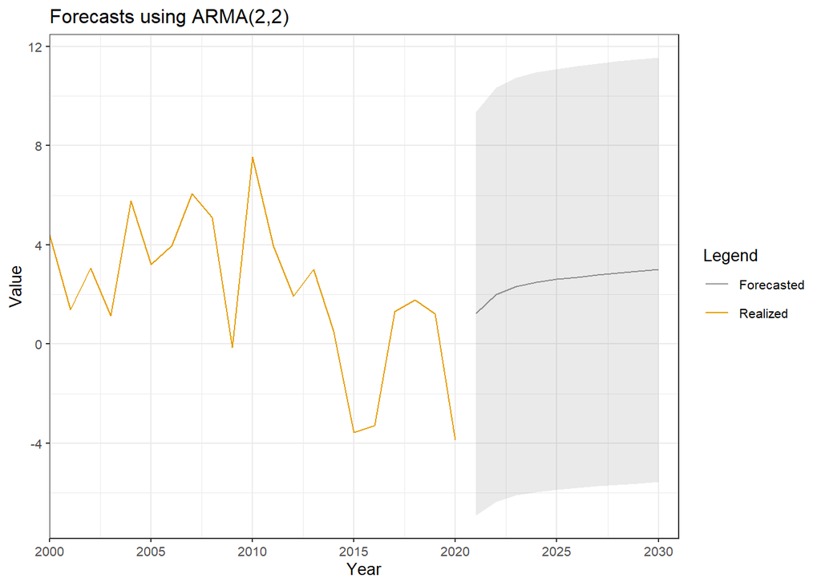

```r
for(i in 1:length(models)){

  # Indicates which model we are estimating
  cat(paste0("RESULTS FOR THE ",models_names[i]," MODEL:\n"))

  # Estimates the model, save in object model and reports objects
  model <- arima(x = df_xts, order = models[[i]], include.mean = T)
  print(lmtest::coeftest(model))
  cat(paste0("AIC: ",AIC(model)),"\n")
  cat(paste0("BIC: ",BIC(model)),"\n")

  # Forecasts
  forecast <- predict(object = model, n.ahead = 10)

  # Creates and fills df_plot with the predicted values
  # This is a small waste of processing power because except for forecast,
  # none of this needs to be iterated
  df_plot <- data.frame(
    "year" = 2000:2030,
    "gdp_growth" = c(data_gdp_brazil$gdp[data_gdp_brazil$data >= 2000], rep(NA,10)),
    "forecast" = c(rep(NA,21),forecast$pred),
    "CI_U" = c(rep(NA, 21), forecast$pred + qnorm(1 - 0.05/2) * forecast$se),
    "CI_L" = c(rep(NA, 21), forecast$pred + qnorm(0.05/2) * forecast$se)
  )

  # Creates the plot
  plot_forecast <- ggplot(data = df_plot, aes(x = year)) +
    geom_line(aes(y = gdp_growth, color = "Realized")) +
    geom_line(aes(y = forecast, color = "Forecasted")) +
    geom_ribbon(aes(ymin = CI_L, ymax = CI_U), alpha = 0.1) +
    scale_x_continuous(
      limits = c(2000, 2031),
      expand = c(0,0),
      breaks = seq(from = 2000, to = 2030, by = 5)
    ) +
    scale_color_manual(
      "Legend", values=cbPalette
    ) +
    theme_bw(base_size = 10) +
    labs(title = paste0("Forecasts using ",models_names[i])) +
    xlab("Year") +
    ylab("Value")

  # Prints the plot
  # We use suppressWarnings because ggplot will tell us it remove NA values
  # This happens because we have created df_plot with intentional NA rows
  suppressWarnings(print(plot_forecast))
}
```

### Among these eight models, which one would you choose as the best model? Explain your choice.

I would choose `ARMA(2,1)` as the best model. Among all the models, `ARMA(2,1)` and `ARMA(1,2)` returned the smallest p-values for the estimated coefficientes. However, `ARMA(2,1)` have the smaller AIC and BIC between these two.

# Question 2

In this question I will follow the step-by-step outlined in code `code03_MC-ma1.R`. Firstly I will set some paramethers:

```r
# Set seed (so we have replicable results) (same as the original code)
set.seed(211216)

# Setup parallel backend to use all but one of the cores (same as the original code)
n.cores <- 10
cl <- makeCluster(n.cores)
registerDoParallel(cl)

# Length of the time series (same as the original code)
capT_vec <- c(4:100, seq(110, 200, 10), seq(250, 500, 50))

# Number of MC repetitions (same as the original code)
M <- 1000

# Allowed distance for convergence in probability (same as the original code)
delta <- c(0.25, 0.2, 0.15, 0.1)
```

## Intercept estimator of $Y_t = c + \theta \epsilon_{t-1} + \epsilon_t$, where $c=0$, $\theta = 0.5$ and $\epsilon_t$ is i.i.d. $N(0,1)$ or i.i.d. $exp(1)$.

### Normal Distribution

We have $\theta = 0.5$. Let’s start with the normal distribution:

```r
theta = 0.5
g = 1
```

We will run a Monte Carlo Experiment by running a parallel loop over sample sizes. But instead of using the estimator of the first moving average coefficient, we will use the estimator of the intercept.

```r
results <- foreach(
  capT = capT_vec, .inorder = TRUE, .errorhandling = "remove", .verbose = FALSE
) %dopar% {
  # Create a dataframe to store the results for each MC repetition
  resultsT <- data.frame(
    "capT" = rep(capT, M),
    "bias" = rep(NA, M),
    "normalized_coef" = rep(NA, M),
    "reject" = rep(NA, M)
  )

  # Loop over MC repetitions
  for (m in 1:M) {
    # Simulate an MA(1) process. If g == 1, it is a Gaussian process.
    if (g == 1) {
      Y <- arima.sim(model = list(ma = theta), n = capT, rand.gen = rnorm)

      # If g == 0, it is a exponential process
    } else {
      Y <- arima.sim(model = list(ma = theta), n = capT, rand.gen = rexp)

    }

    # Estimate an MA(1) model
    ma1 <- arima(
      x = Y,
      order = c(0, 0, 1),
      include.mean = TRUE
    )

    ###################################
    # Store the results
    ###################################
    # Store the estimated bias
    # Here the estmated coefficient of the intercept is ma1$coef[2]
    resultsT$bias[m] <- ma1$coef[2] - 0

    # Store the normalized coefficient
    # The variance of the estimated coefficient of the intercept is ma1$var.coef[2,2]
    resultsT$normalized_coef[m] <- (ma1$coef[2] - 0) / sqrt(ma1$var.coef[2,2])

    # Store the test decision
    resultsT$reject[m] <- as.numeric(
      abs((ma1$coef[2] - 0) / sqrt(ma1$var.coef[2,2])) >= qnorm(0.975)
    )

  }

  # Return the results
  return(resultsT)
}

# Stop parallel backend
stopCluster(cl)
```

#### Convergence in probability

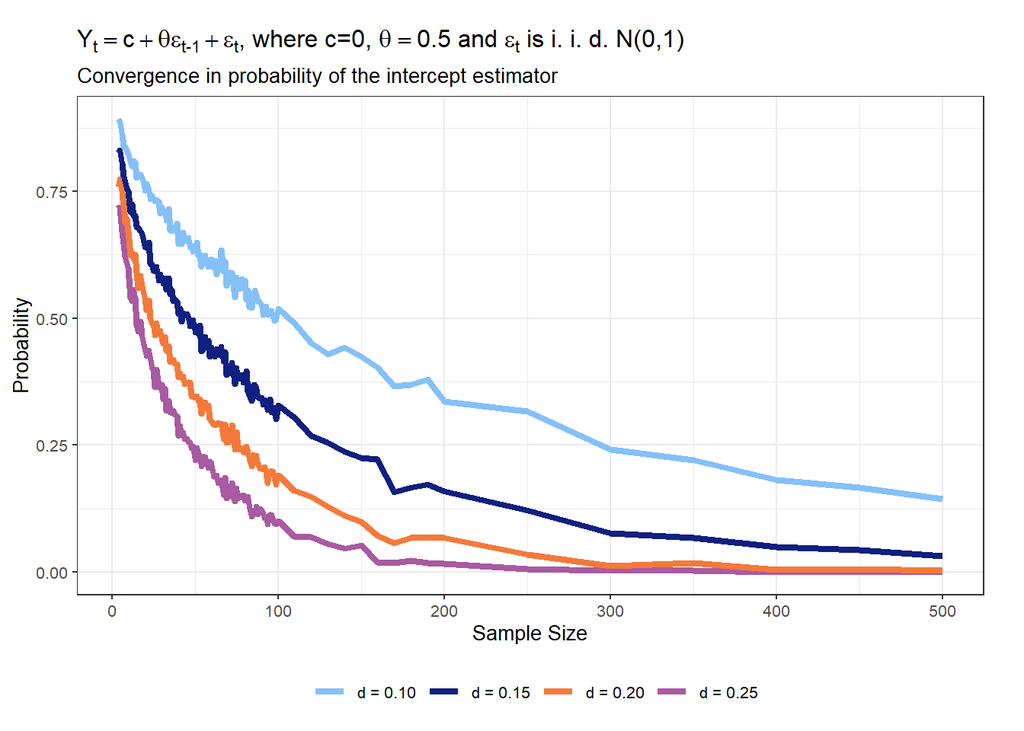

```r
# Create a matrix to store the results
probs <- data.frame(
  "capT" = capT_vec,
  "delta1" = rep(NA, length(capT_vec)),
  "delta2" = rep(NA, length(capT_vec)),
  "delta3" = rep(NA, length(capT_vec)),
  "delta4" = rep(NA, length(capT_vec))
)

# Loop over sample size
for (t in 1:length(capT_vec)) {
  # Loop over values of delta: Once more, I chose I slow code so that I would
  # save my own time.
  for (d in delta) {
    # Compare all MC estimates against delta
    temp <- abs(results[[t]]$bias) > d

    # Compute the probability of the bias being small
    probs[t, which(d == delta) + 1] <- mean(temp)
  }

}

# Create a plot with the results
gg <- ggplot(data = probs, aes(x = capT)) +
  theme_bw(base_size = 10) +
  theme(plot.margin = unit(c(5, 7, 2, 2), "mm")) +
  xlab("Sample Size") + ylab("Probability") +
  geom_line(
    aes(y = delta1, color = "d = 0.25"),
    size = 1.5
  ) +
  geom_line(
    aes(y = delta2, color = "d = 0.20"),
    size = 1.5
  ) +
  geom_line(
    aes(y = delta3, color = "d = 0.15"),
    size = 1.5
  ) +
  geom_line(
    aes(y = delta4, color = "d = 0.10"),
    size = 1.5
  ) +
  scale_colour_manual(values = c(
    "#85C0F9", "#0F2080", "#F5793A", "#A95AA1"
  )) +
  theme(
    legend.title = element_blank(),
    legend.position = "bottom"
  ) +
  labs(subtitle = "Convergence in probability of the intercept estimator", title = unname(TeX("$Y_t = c + \\theta \\epsilon_{t-1} + \\epsilon_t$, where $c=0$, $\\theta = 0.5$ and $\\epsilon_t$ is i.i.d. $N(0,1)$")))

print(gg)
```

#### Convergence in distribution

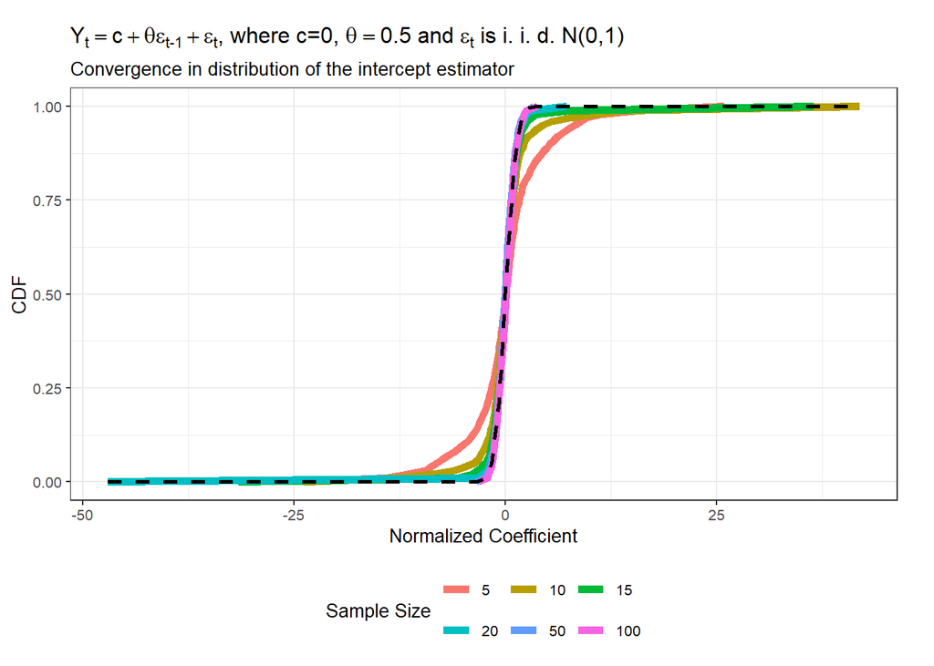

```r
# Collect the CDF of our normalized coefficient for each sample size
#######################################
# Create a data frame to store the results
temp <- data.frame(
  "capT" = rep(NA, 6 * 101),
  "Fy" = rep(NA, 6 * 101),
  "Qy" = rep(NA, 6 * 101)
)

# Find the relevant sample size indexes
i_vec <- which(capT_vec %in% c(5, 10, 15, 20, 50, 100))

# Loop over the sample sizes
for (i in i_vec) {
  # Index within i_vec
  j <- which(i == i_vec)

  # Write the sample size
  temp$capT[(1 + (j - 1) * 101):(j * 101)] <- results[[i]]$capT[1]

  # Write down the probabilities
  temp$Fy[(1 + (j - 1) * 101):(j * 101)] <- seq(0, 1, 0.01)

  # Write down the quantiles
  temp$Qy[(1 + (j - 1) * 101):(j * 101)] <- quantile(
    results[[i]]$normalized_coef, probs = seq(0, 1, 0.01), na.rm = TRUE
  )
}

# Write capT as a factor to enforce the ordering
temp$capT <- factor(temp$capT)

# Create a ggplot
gg <- ggplot(temp, aes(x = Qy, y = Fy)) +
  theme_bw(base_size = 10) +
  theme(plot.margin = unit(c(5, 7, 2, 2), "mm")) +
  xlab("Normalized Coefficient") + ylab("CDF") +
  geom_line(aes(colour = capT), size = 2) +
  stat_function(fun = pnorm, size = 1, linetype = "dashed")  +
  theme(
    legend.position = "bottom"
  ) + guides(
    colour = guide_legend(nrow = 2, byrow = TRUE, title = "Sample Size")
  ) +
  labs(subtitle = "Convergence in distribution of the intercept estimator", title = unname(TeX("$Y_t = c + \\theta \\epsilon_{t-1} + \\epsilon_t$, where $c=0$, $\\theta = 0.5$ and $\\epsilon_t$ is i.i.d. $N(0,1)$")))

# Show the plot
print(gg)
```

#### Test size control

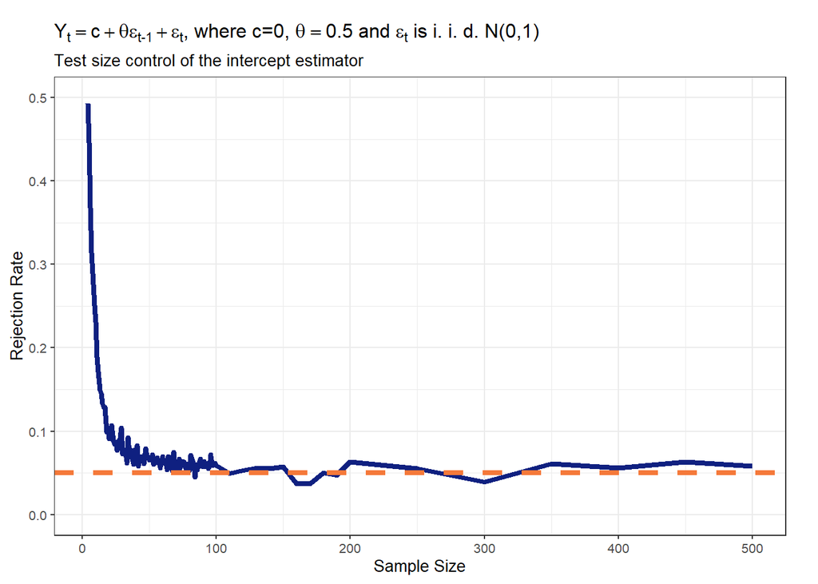

```r
# Create a matrix to store the results
rej_rate <- data.frame(
  "capT" = capT_vec,
  "rej" = rep(NA, length(capT_vec))
)

# Loop over sample size
for (t in 1:length(capT_vec)) {
  # Compute the test size
  rej_rate[t, 2] <- mean(results[[t]]$reject, na.rm = TRUE)

}

# Create a plot with the results
gg <- ggplot(data = rej_rate, aes(x = capT)) +
  theme_bw(base_size = 10) +
  theme(plot.margin = unit(c(5, 7, 2, 2), "mm")) +
  xlab("Sample Size") + ylab("Rejection Rate") +
  scale_y_continuous(
    limits = c(0, 0.5)
  ) +
  geom_line(
    aes(y = rej),
    size = 1.5, colour = "#0F2080"
  ) +
  geom_hline(
    yintercept = 0.05, size = 1.5, linetype = "dashed", color = "#F5793A"
  )  +
  labs(subtitle = "Test size control of the intercept estimator", title = unname(TeX("$Y_t = c + \\theta \\epsilon_{t-1} + \\epsilon_t$, where $c=0$, $\\theta = 0.5$ and $\\epsilon_t$ is i.i.d. $N(0,1)$")))

suppressWarnings(print(gg))
```

### Expontential Distribution

We have $\theta = 0.5$. But now $g = 0$.

```r
theta = 0.5
g = 0

# Set seed (so we have replicable results) (same as the original code)
set.seed(211216)

# Setup parallel backend to use all but one of the cores (same as the original code)
n.cores <- 10
cl <- makeCluster(n.cores)
registerDoParallel(cl)
```

We will run a Monte Carlo Experiment by running a parallel loop over sample sizes. But instead of using the estimator of the first moving average coefficient, we will use the estimator of the intercept.

```r
results <- foreach(
  capT = capT_vec, .inorder = TRUE, .errorhandling = "remove", .verbose = FALSE
) %dopar% {
  # Create a dataframe to store the results for each MC repetition
  resultsT <- data.frame(
    "capT" = rep(capT, M),
    "bias" = rep(NA, M),
    "normalized_coef" = rep(NA, M),
    "reject" = rep(NA, M)
  )

  # Loop over MC repetitions
  for (m in 1:M) {
    # Simulate an MA(1) process. If g == 1, it is a Gaussian process.
    if (g == 1) {
      Y <- arima.sim(model = list(ma = theta), n = capT, rand.gen = rnorm)

      # If g == 0, it is a exponential process
    } else {
      Y <- arima.sim(model = list(ma = theta), n = capT, rand.gen = rexp)

    }

    # Estimate an MA(1) model
    ma1 <- arima(
      x = Y,
      order = c(0, 0, 1),
      include.mean = TRUE
    )

    ###################################
    # Store the results
    ###################################
    # Store the estimated bias
    # Here the estmated coefficient of the intercept is ma1$coef[2]
    resultsT$bias[m] <- ma1$coef[2] - 0

    # Store the normalized coefficient
    # The variance of the estimated coefficient of the intercept is ma1$var.coef[2,2]
    resultsT$normalized_coef[m] <- (ma1$coef[2] - 0) / sqrt(ma1$var.coef[2,2])

    # Store the test decision
    resultsT$reject[m] <- as.numeric(
      abs((ma1$coef[2] - 0) / sqrt(ma1$var.coef[2,2])) >= qnorm(0.975)
    )

  }

  # Return the results
  return(resultsT)
}

# Stop parallel backend
stopCluster(cl)
```

#### Convergence in probability

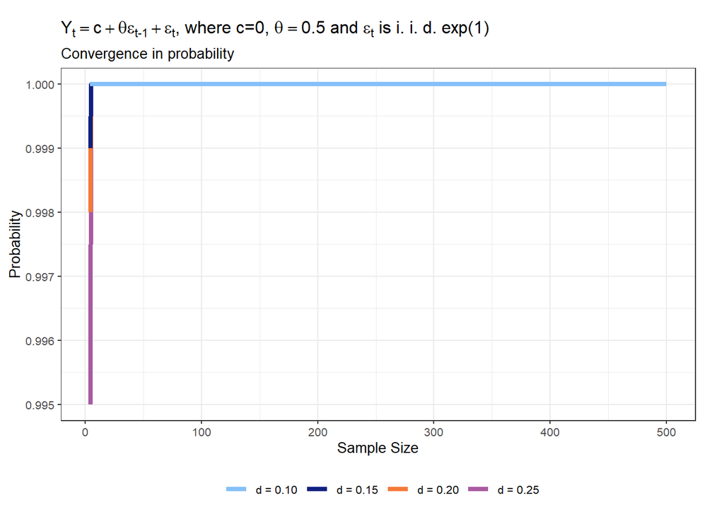

```r
# Create a matrix to store the results
probs <- data.frame(
  "capT" = capT_vec,
  "delta1" = rep(NA, length(capT_vec)),
  "delta2" = rep(NA, length(capT_vec)),
  "delta3" = rep(NA, length(capT_vec)),
  "delta4" = rep(NA, length(capT_vec))
)

# Loop over sample size
for (t in 1:length(capT_vec)) {
  # Loop over values of delta: Once more, I chose I slow code so that I would
  # save my own time.
  for (d in delta) {
    # Compare all MC estimates against delta
    temp <- abs(results[[t]]$bias) > d

    # Compute the probability of the bias being small
    probs[t, which(d == delta) + 1] <- mean(temp)
  }

}

# Create a plot with the results
gg <- ggplot(data = probs, aes(x = capT)) +
  theme_bw(base_size = 10) +
  theme(plot.margin = unit(c(5, 7, 2, 2), "mm")) +
  xlab("Sample Size") + ylab("Probability") +
  geom_line(
    aes(y = delta1, color = "d = 0.25"),
    size = 1.5
  ) +
  geom_line(
    aes(y = delta2, color = "d = 0.20"),
    size = 1.5
  ) +
  geom_line(
    aes(y = delta3, color = "d = 0.15"),
    size = 1.5
  ) +
  geom_line(
    aes(y = delta4, color = "d = 0.10"),
    size = 1.5
  ) +
  scale_colour_manual(values = c(
    "#85C0F9", "#0F2080", "#F5793A", "#A95AA1"
  )) +
  theme(
    legend.title = element_blank(),
    legend.position = "bottom"
  ) +
  labs(subtitle = "Convergence in probability", title = unname(TeX("$Y_t = c + \\theta \\epsilon_{t-1} + \\epsilon_t$, where $c=0$, $\\theta = 0.5$ and $\\epsilon_t$ is i.i.d. $exp(1)$")))

print(gg)
```

#### Convergence in distribution

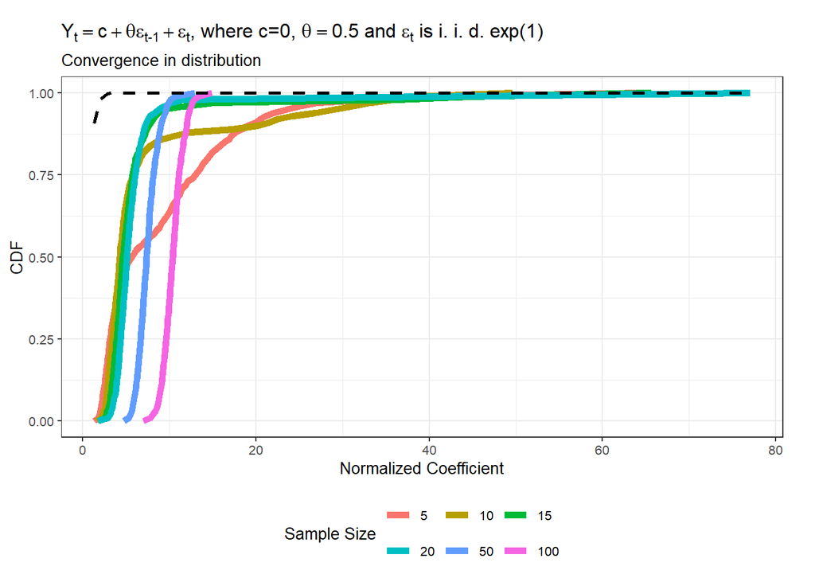

```r
# Collect the CDF of our normalized coefficient for each sample size
#######################################
# Create a data frame to store the results
temp <- data.frame(
  "capT" = rep(NA, 6 * 101),
  "Fy" = rep(NA, 6 * 101),
  "Qy" = rep(NA, 6 * 101)
)

# Find the relevant sample size indexes
i_vec <- which(capT_vec %in% c(5, 10, 15, 20, 50, 100))

# Loop over the sample sizes
for (i in i_vec) {
  # Index within i_vec
  j <- which(i == i_vec)

  # Write the sample size
  temp$capT[(1 + (j - 1) * 101):(j * 101)] <- results[[i]]$capT[1]

  # Write down the probabilities
  temp$Fy[(1 + (j - 1) * 101):(j * 101)] <- seq(0, 1, 0.01)

  # Write down the quantiles
  temp$Qy[(1 + (j - 1) * 101):(j * 101)] <- quantile(
    results[[i]]$normalized_coef, probs = seq(0, 1, 0.01), na.rm = TRUE
  )
}

# Write capT as a factor to enforce the ordering
temp$capT <- factor(temp$capT)

# Create a ggplot
gg <- ggplot(temp, aes(x = Qy, y = Fy)) +
  theme_bw(base_size = 10) +
  theme(plot.margin = unit(c(5, 7, 2, 2), "mm")) +
  xlab("Normalized Coefficient") + ylab("CDF") +
  geom_line(aes(colour = capT), size = 2) +
  stat_function(fun = pnorm, size = 1, linetype = "dashed")  +
  theme(
    legend.position = "bottom"
  ) + guides(
    colour = guide_legend(nrow = 2, byrow = TRUE, title = "Sample Size")
  ) +
  labs(subtitle = "Convergence in distribution", title = unname(TeX("$Y_t = c + \\theta \\epsilon_{t-1} + \\epsilon_t$, where $c=0$, $\\theta = 0.5$ and $\\epsilon_t$ is i.i.d. $exp(1)$")))

# Show the plot
print(gg)
```

#### Test size control

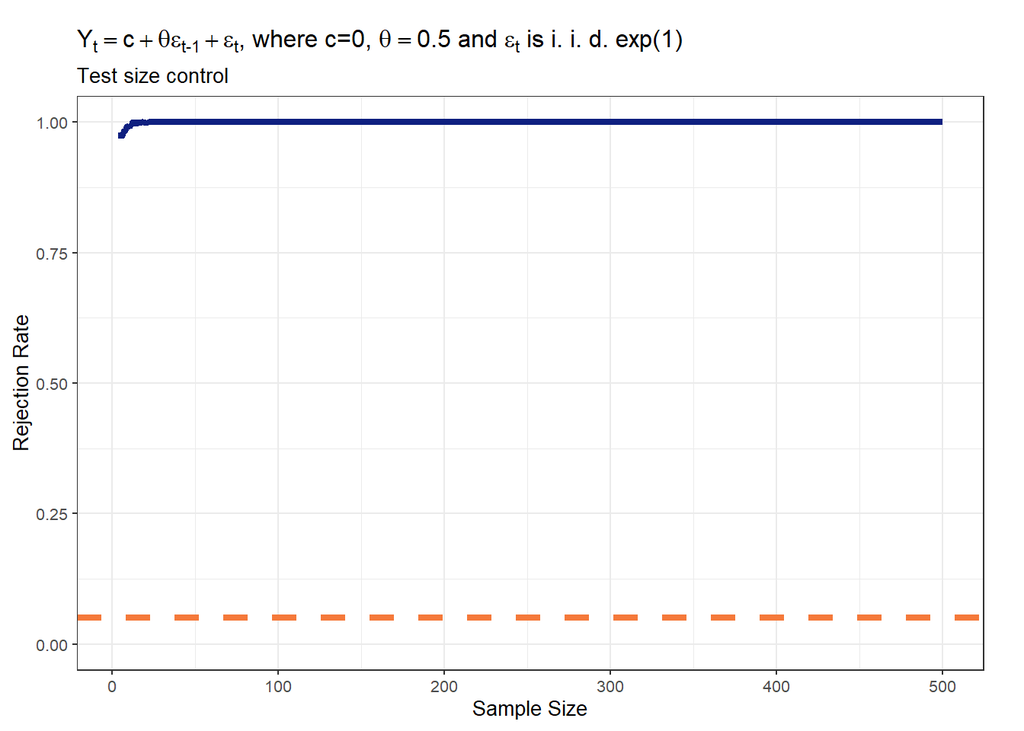

```r
# Create a matrix to store the results
rej_rate <- data.frame(
  "capT" = capT_vec,
  "rej" = rep(NA, length(capT_vec))
)

# Loop over sample size
for (t in 1:length(capT_vec)) {
  # Compute the test size
  rej_rate[t, 2] <- mean(results[[t]]$reject, na.rm = TRUE)

}

# Create a plot with the results
gg <- ggplot(data = rej_rate, aes(x = capT)) +
  theme_bw(base_size = 10) +
  theme(plot.margin = unit(c(5, 7, 2, 2), "mm")) +
  xlab("Sample Size") + ylab("Rejection Rate") +
  scale_y_continuous(
    limits = c(0, 1)
  ) +
  geom_line(
    aes(y = rej),
    size = 1.5, colour = "#0F2080"
  ) +
  geom_hline(
    yintercept = 0.05, size = 1.5, linetype = "dashed", color = "#F5793A"
  )  +
  labs(subtitle = "Test size control", title = unname(TeX("$Y_t = c + \\theta \\epsilon_{t-1} + \\epsilon_t$, where $c=0$, $\\theta = 0.5$ and $\\epsilon_t$ is i.i.d. $exp(1)$")))

print(gg)
```

To keep things organized, I will clean the environment before each model.

```r
rm(list=ls())

# Set seed (so we have replicable results) (same as the original code)
set.seed(211216)

# Setup parallel backend to use all but one of the cores (same as the original code)
n.cores <- 10
cl <- makeCluster(n.cores)
registerDoParallel(cl)

# Length of the time series (same as the original code)
capT_vec <- c(4:100, seq(110, 200, 10), seq(250, 500, 50))

# Number of MC repetitions (same as the original code)
M <- 1000

# Allowed distance for convergence in probability (same as the original code)
delta <- c(0.25, 0.2, 0.15, 0.1)
```

### Normal Distribution

```r
phi = 0.5
g = 1
```

We will run a Monte Carlo Experiment by running a parallel loop over sample sizes. But instead of using the estimator of the first moving average coefficient, we will use the estimator of the intercept.

```r
results <- foreach(
  capT = capT_vec, .inorder = TRUE, .errorhandling = "remove", .verbose = FALSE
) %dopar% {
  # Create a dataframe to store the results for each MC repetition
  resultsT <- data.frame(
    "capT" = rep(capT, M),
    "bias" = rep(NA, M),
    "normalized_coef" = rep(NA, M),
    "reject" = rep(NA, M)
  )

  # Loop over MC repetitions
  for (m in 1:M) {
    # Simulate an MA(1) process. If g == 1, it is a Gaussian process.
    if (g == 1) {
      Y <- arima.sim(model = list(ma = phi), n = capT, rand.gen = rnorm)

      # If g == 0, it is a exponential process
    } else {
      Y <- arima.sim(model = list(ma = phi), n = capT, rand.gen = rexp)

    }

    # Estimate an MA(1) model
    ma1 <- arima(
      x = Y,
      order = c(0, 0, 1),
      include.mean = TRUE
    )

    ###################################
    # Store the results
    ###################################
    # Store the estimated bias
    # Here the estmated coefficient of the intercept is ma1$coef[2]
    resultsT$bias[m] <- ma1$coef[2] - 0

    # Store the normalized coefficient
    # The variance of the estimated coefficient of the intercept is ma1$var.coef[2,2]
    resultsT$normalized_coef[m] <- (ma1$coef[2] - 0) / sqrt(ma1$var.coef[2,2])

    # Store the test decision
    resultsT$reject[m] <- as.numeric(
      abs((ma1$coef[2] - 0) / sqrt(ma1$var.coef[2,2])) >= qnorm(0.975)
    )

  }

  # Return the results
  return(resultsT)
}

# Stop parallel backend
stopCluster(cl)
```

#### Convergence in probability

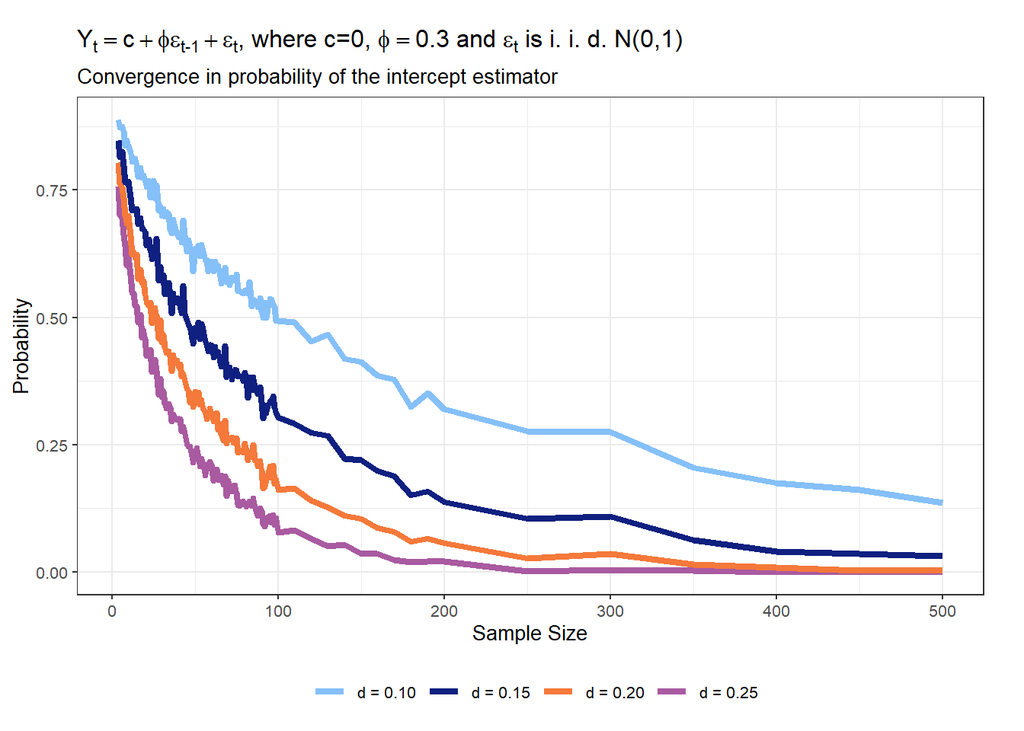

```r
# Create a matrix to store the results
probs <- data.frame(
  "capT" = capT_vec,
  "delta1" = rep(NA, length(capT_vec)),
  "delta2" = rep(NA, length(capT_vec)),
  "delta3" = rep(NA, length(capT_vec)),
  "delta4" = rep(NA, length(capT_vec))
)

# Loop over sample size
for (t in 1:length(capT_vec)) {
  # Loop over values of delta: Once more, I chose I slow code so that I would
  # save my own time.
  for (d in delta) {
    # Compare all MC estimates against delta
    temp <- abs(results[[t]]$bias) > d

    # Compute the probability of the bias being small
    probs[t, which(d == delta) + 1] <- mean(temp)
  }

}

# Create a plot with the results
gg <- ggplot(data = probs, aes(x = capT)) +
  theme_bw(base_size = 10) +
  theme(plot.margin = unit(c(5, 7, 2, 2), "mm")) +
  xlab("Sample Size") + ylab("Probability") +
  geom_line(
    aes(y = delta1, color = "d = 0.25"),
    size = 1.5
  ) +
  geom_line(
    aes(y = delta2, color = "d = 0.20"),
    size = 1.5
  ) +
  geom_line(
    aes(y = delta3, color = "d = 0.15"),
    size = 1.5
  ) +
  geom_line(
    aes(y = delta4, color = "d = 0.10"),
    size = 1.5
  ) +
  scale_colour_manual(values = c(
    "#85C0F9", "#0F2080", "#F5793A", "#A95AA1"
  )) +
  theme(
    legend.title = element_blank(),
    legend.position = "bottom"
  ) +
  labs(subtitle = "Convergence in probability of the intercept estimator", title = unname(TeX("$Y_t = c + \\phi \\epsilon_{t-1} + \\epsilon_t$, where $c=0$, $\\phi = 0.3$ and $\\epsilon_t$ is i.i.d. $N(0,1)$")))

print(gg)
```

#### Convergence in distribution

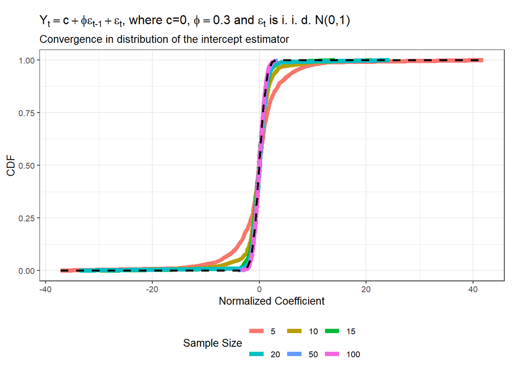

```r
# Collect the CDF of our normalized coefficient for each sample size
#######################################
# Create a data frame to store the results
temp <- data.frame(
  "capT" = rep(NA, 6 * 101),
  "Fy" = rep(NA, 6 * 101),
  "Qy" = rep(NA, 6 * 101)
)

# Find the relevant sample size indexes
i_vec <- which(capT_vec %in% c(5, 10, 15, 20, 50, 100))

# Loop over the sample sizes
for (i in i_vec) {
  # Index within i_vec
  j <- which(i == i_vec)

  # Write the sample size
  temp$capT[(1 + (j - 1) * 101):(j * 101)] <- results[[i]]$capT[1]

  # Write down the probabilities
  temp$Fy[(1 + (j - 1) * 101):(j * 101)] <- seq(0, 1, 0.01)

  # Write down the quantiles
  temp$Qy[(1 + (j - 1) * 101):(j * 101)] <- quantile(
    results[[i]]$normalized_coef, probs = seq(0, 1, 0.01), na.rm = TRUE
  )
}

# Write capT as a factor to enforce the ordering
temp$capT <- factor(temp$capT)

# Create a ggplot
gg <- ggplot(temp, aes(x = Qy, y = Fy)) +
  theme_bw(base_size = 10) +
  theme(plot.margin = unit(c(5, 7, 2, 2), "mm")) +
  xlab("Normalized Coefficient") + ylab("CDF") +
  geom_line(aes(colour = capT), size = 2) +
  stat_function(fun = pnorm, size = 1, linetype = "dashed")  +
  theme(
    legend.position = "bottom"
  ) + guides(
    colour = guide_legend(nrow = 2, byrow = TRUE, title = "Sample Size")
  ) +
  labs(subtitle = "Convergence in distribution of the intercept estimator", title = unname(TeX("$Y_t = c + \\phi \\epsilon_{t-1} + \\epsilon_t$, where $c=0$, $\\phi = 0.3$ and $\\epsilon_t$ is i.i.d. $N(0,1)$")))

# Show the plot
print(gg)
```

#### Test size control

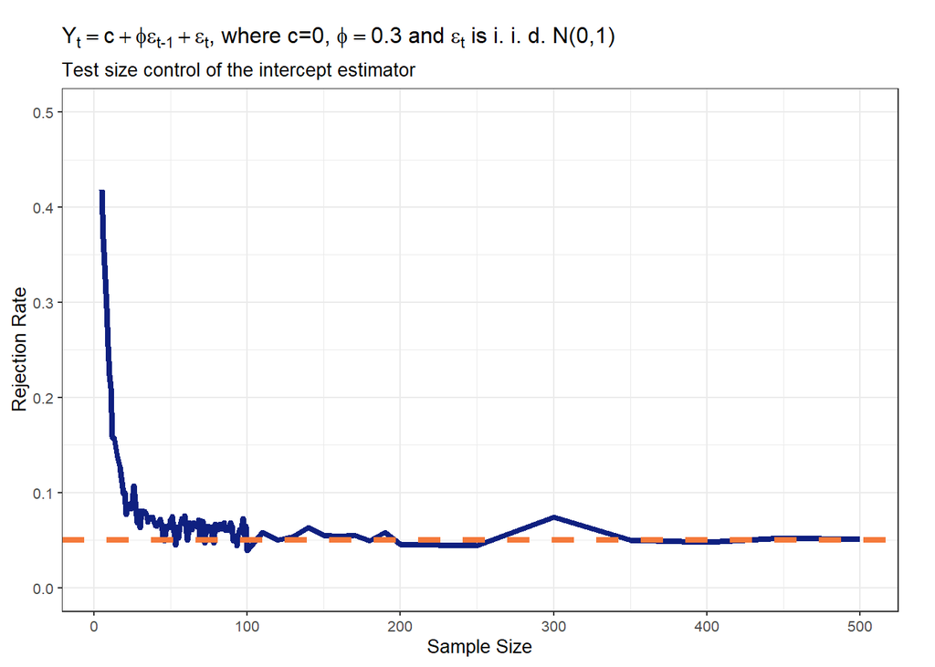

```r
# Create a matrix to store the results
rej_rate <- data.frame(
  "capT" = capT_vec,
  "rej" = rep(NA, length(capT_vec))
)

# Loop over sample size
for (t in 1:length(capT_vec)) {
  # Compute the test size
  rej_rate[t, 2] <- mean(results[[t]]$reject, na.rm = TRUE)

}

# Create a plot with the results
gg <- ggplot(data = rej_rate, aes(x = capT)) +
  theme_bw(base_size = 10) +
  theme(plot.margin = unit(c(5, 7, 2, 2), "mm")) +
  xlab("Sample Size") + ylab("Rejection Rate") +
  scale_y_continuous(
    limits = c(0, 0.5)
  ) +
  geom_line(
    aes(y = rej),
    size = 1.5, colour = "#0F2080"
  ) +
  geom_hline(
    yintercept = 0.05, size = 1.5, linetype = "dashed", color = "#F5793A"
  )  +
  labs(subtitle = "Test size control of the intercept estimator", title = unname(TeX("$Y_t = c + \\phi \\epsilon_{t-1} + \\epsilon_t$, where $c=0$, $\\phi = 0.3$ and $\\epsilon_t$ is i.i.d. $N(0,1)$")))

suppressWarnings(print(gg))
```

### Expontential Distribution

We have $\phi = 0.3$. But now $g = 0$.

```r
phi = 0.3
g = 0

# Set seed (so we have replicable results) (same as the original code)
set.seed(211216)

# Setup parallel backend to use all but one of the cores (same as the original code)
n.cores <- 10
cl <- makeCluster(n.cores)
registerDoParallel(cl)
```

We will run a Monte Carlo Experiment by running a parallel loop over sample sizes. But instead of using the estimator of the first moving average coefficient, we will use the estimator of the intercept.

```r
results <- foreach(
  capT = capT_vec, .inorder = TRUE, .errorhandling = "remove", .verbose = FALSE
) %dopar% {
  # Create a dataframe to store the results for each MC repetition
  resultsT <- data.frame(
    "capT" = rep(capT, M),
    "bias" = rep(NA, M),
    "normalized_coef" = rep(NA, M),
    "reject" = rep(NA, M)
  )

  # Loop over MC repetitions
  for (m in 1:M) {
    # Simulate an MA(1) process. If g == 1, it is a Gaussian process.
    if (g == 1) {
      Y <- arima.sim(model = list(ma = phi), n = capT, rand.gen = rnorm)

      # If g == 0, it is a exponential process
    } else {
      Y <- arima.sim(model = list(ma = phi), n = capT, rand.gen = rexp)

    }

    # Estimate an MA(1) model
    ma1 <- arima(
      x = Y,
      order = c(0, 0, 1),
      include.mean = TRUE
    )

    ###################################
    # Store the results
    ###################################
    # Store the estimated bias
    # Here the estmated coefficient of the intercept is ma1$coef[2]
    resultsT$bias[m] <- ma1$coef[2] - 0

    # Store the normalized coefficient
    # The variance of the estimated coefficient of the intercept is ma1$var.coef[2,2]
    resultsT$normalized_coef[m] <- (ma1$coef[2] - 0) / sqrt(ma1$var.coef[2,2])

    # Store the test decision
    resultsT$reject[m] <- as.numeric(
      abs((ma1$coef[2] - 0) / sqrt(ma1$var.coef[2,2])) >= qnorm(0.975)
    )

  }

  # Return the results
  return(resultsT)
}

# Stop parallel backend
stopCluster(cl)
```

#### Convergence in probability

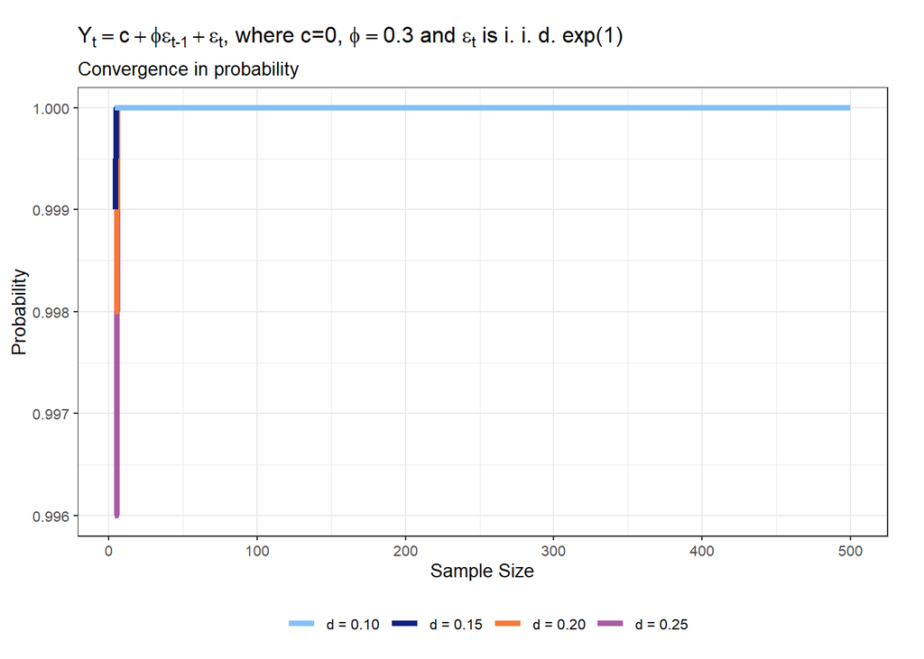

```r
# Create a matrix to store the results
probs <- data.frame(
  "capT" = capT_vec,
  "delta1" = rep(NA, length(capT_vec)),
  "delta2" = rep(NA, length(capT_vec)),
  "delta3" = rep(NA, length(capT_vec)),
  "delta4" = rep(NA, length(capT_vec))
)

# Loop over sample size
for (t in 1:length(capT_vec)) {
  # Loop over values of delta: Once more, I chose I slow code so that I would
  # save my own time.
  for (d in delta) {
    # Compare all MC estimates against delta
    temp <- abs(results[[t]]$bias) > d

    # Compute the probability of the bias being small
    probs[t, which(d == delta) + 1] <- mean(temp)
  }

}

# Create a plot with the results
gg <- ggplot(data = probs, aes(x = capT)) +
  theme_bw(base_size = 10) +
  theme(plot.margin = unit(c(5, 7, 2, 2), "mm")) +
  xlab("Sample Size") + ylab("Probability") +
  geom_line(
    aes(y = delta1, color = "d = 0.25"),
    size = 1.5
  ) +
  geom_line(
    aes(y = delta2, color = "d = 0.20"),
    size = 1.5
  ) +
  geom_line(
    aes(y = delta3, color = "d = 0.15"),
    size = 1.5
  ) +
  geom_line(
    aes(y = delta4, color = "d = 0.10"),
    size = 1.5
  ) +
  scale_colour_manual(values = c(
    "#85C0F9", "#0F2080", "#F5793A", "#A95AA1"
  )) +
  theme(
    legend.title = element_blank(),
    legend.position = "bottom"
  ) +
  labs(subtitle = "Convergence in probability", title = unname(TeX("$Y_t = c + \\phi \\epsilon_{t-1} + \\epsilon_t$, where $c=0$, $\\phi = 0.3$ and $\\epsilon_t$ is i.i.d. $exp(1)$")))

print(gg)
```

#### Convergence in distribution

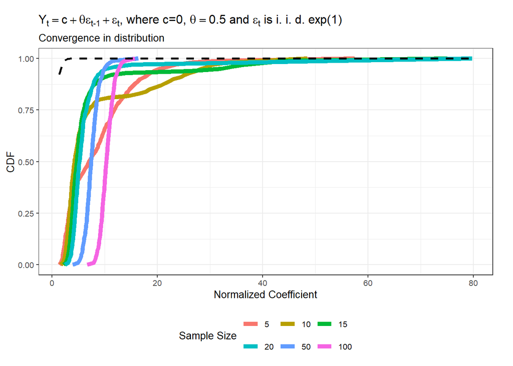

```r
# Collect the CDF of our normalized coefficient for each sample size
#######################################
# Create a data frame to store the results
temp <- data.frame(
  "capT" = rep(NA, 6 * 101),
  "Fy" = rep(NA, 6 * 101),
  "Qy" = rep(NA, 6 * 101)
)

# Find the relevant sample size indexes
i_vec <- which(capT_vec %in% c(5, 10, 15, 20, 50, 100))

# Loop over the sample sizes
for (i in i_vec) {
  # Index within i_vec
  j <- which(i == i_vec)

  # Write the sample size
  temp$capT[(1 + (j - 1) * 101):(j * 101)] <- results[[i]]$capT[1]

  # Write down the probabilities
  temp$Fy[(1 + (j - 1) * 101):(j * 101)] <- seq(0, 1, 0.01)

  # Write down the quantiles
  temp$Qy[(1 + (j - 1) * 101):(j * 101)] <- quantile(
    results[[i]]$normalized_coef, probs = seq(0, 1, 0.01), na.rm = TRUE
  )
}

# Write capT as a factor to enforce the ordering
temp$capT <- factor(temp$capT)

# Create a ggplot
gg <- ggplot(temp, aes(x = Qy, y = Fy)) +
  theme_bw(base_size = 10) +
  theme(plot.margin = unit(c(5, 7, 2, 2), "mm")) +
  xlab("Normalized Coefficient") + ylab("CDF") +
  geom_line(aes(colour = capT), size = 2) +
  stat_function(fun = pnorm, size = 1, linetype = "dashed")  +
  theme(
    legend.position = "bottom"
  ) + guides(
    colour = guide_legend(nrow = 2, byrow = TRUE, title = "Sample Size")
  ) +
  labs(subtitle = "Convergence in distribution", title = unname(TeX("$Y_t = c + \\theta \\epsilon_{t-1} + \\epsilon_t$, where $c=0$, $\\theta = 0.5$ and $\\epsilon_t$ is i.i.d. $exp(1)$")))

# Show the plot
print(gg)
```

#### Test size control

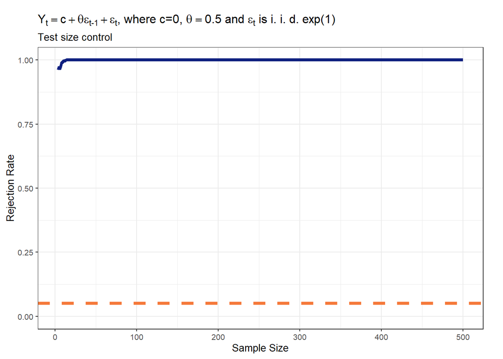

```r
# Create a matrix to store the results
rej_rate <- data.frame(
  "capT" = capT_vec,
  "rej" = rep(NA, length(capT_vec))
)

# Loop over sample size
for (t in 1:length(capT_vec)) {
  # Compute the test size
  rej_rate[t, 2] <- mean(results[[t]]$reject, na.rm = TRUE)

}

# Create a plot with the results
gg <- ggplot(data = rej_rate, aes(x = capT)) +
  theme_bw(base_size = 10) +
  theme(plot.margin = unit(c(5, 7, 2, 2), "mm")) +
  xlab("Sample Size") + ylab("Rejection Rate") +
  scale_y_continuous(
    limits = c(0, 1)
  ) +
  geom_line(
    aes(y = rej),
    size = 1.5, colour = "#0F2080"
  ) +
  geom_hline(
    yintercept = 0.05, size = 1.5, linetype = "dashed", color = "#F5793A"
  )  +
  labs(subtitle = "Test size control", title = unname(TeX("$Y_t = c + \\theta \\epsilon_{t-1} + \\epsilon_t$, where $c=0$, $\\theta = 0.5$ and $\\epsilon_t$ is i.i.d. $exp(1)$")))

print(gg)
```